# Introduction to Machine Learning

Final Project Code

Author

Drew Benedum, Eric Shin, & Zach Stabrowski

Published

March 30, 2025

# Final Project Code

```r
library(ggplot2)
library(readr)
library(rpart)
library(tidyverse)
library(randomForest)
library(partykit)
library(class)
```

## Part 1: Download the necessary data

```r
#Assigning the cancer data as an object
cancer <- read_csv("C:/Users/zstab/OneDrive/Desktop/Intro to Machine Learning/Datasets/FNA_cancer.csv")
#Setting the diagnosis variable as a factor
cancer$diagnosis <- as.factor(cancer$diagnosis)
#Converting variables to valid names
colnames(cancer) <- make.names(colnames(cancer))
# provide a glimpse of the data set
glimpse(cancer)
```

```
Rows: 568
Columns: 33
$ id                      <dbl> 842302, 842517, 84300903, 84348301, 84358402, …
$ diagnosis               <fct> M, M, M, M, M, M, M, M, M, M, M, M, M, M, M, M…
$ radius_mean             <dbl> 17.990, 20.570, 19.690, 11.420, 20.290, 12.450…
$ texture_mean            <dbl> 10.38, 17.77, 21.25, 20.38, 14.34, 15.70, 19.9…
$ perimeter_mean          <dbl> 122.80, 132.90, 130.00, 77.58, 135.10, 82.57, …
$ area_mean               <dbl> 1001.0, 1326.0, 1203.0, 386.1, 1297.0, 477.1, …
$ smoothness_mean         <dbl> 0.11840, 0.08474, 0.10960, 0.14250, 0.10030, 0…
$ compactness_mean        <dbl> 0.27760, 0.07864, 0.15990, 0.28390, 0.13280, 0…
$ concavity_mean          <dbl> 0.30010, 0.08690, 0.19740, 0.24140, 0.19800, 0…
$ concave.points_mean     <dbl> 0.14710, 0.07017, 0.12790, 0.10520, 0.10430, 0…
$ symmetry_mean           <dbl> 0.2419, 0.1812, 0.2069, 0.2597, 0.1809, 0.2087…
$ fractal_dimension_mean  <dbl> 0.07871, 0.05667, 0.05999, 0.09744, 0.05883, 0…
$ radius_se               <dbl> 1.0950, 0.5435, 0.7456, 0.4956, 0.7572, 0.3345…
```

[output cut: 20 more lines]

## Part 2: Perform basic EDA

```r
# the last column appears to be entirely NA values, so we will remove it from the data
summary(cancer$...33)
```

```
   Mode    NA's
logical     568
```

```r
# the id variable is also not pertinent as a predictor, so we will remove that as well
cancer <- cancer %>% select(-c(...33, id))
glimpse(cancer)
```

```
Rows: 568
Columns: 31
$ diagnosis               <fct> M, M, M, M, M, M, M, M, M, M, M, M, M, M, M, M…
$ radius_mean             <dbl> 17.990, 20.570, 19.690, 11.420, 20.290, 12.450…
$ texture_mean            <dbl> 10.38, 17.77, 21.25, 20.38, 14.34, 15.70, 19.9…
$ perimeter_mean          <dbl> 122.80, 132.90, 130.00, 77.58, 135.10, 82.57, …
$ area_mean               <dbl> 1001.0, 1326.0, 1203.0, 386.1, 1297.0, 477.1, …
$ smoothness_mean         <dbl> 0.11840, 0.08474, 0.10960, 0.14250, 0.10030, 0…
$ compactness_mean        <dbl> 0.27760, 0.07864, 0.15990, 0.28390, 0.13280, 0…
$ concavity_mean          <dbl> 0.30010, 0.08690, 0.19740, 0.24140, 0.19800, 0…
$ concave.points_mean     <dbl> 0.14710, 0.07017, 0.12790, 0.10520, 0.10430, 0…
$ symmetry_mean           <dbl> 0.2419, 0.1812, 0.2069, 0.2597, 0.1809, 0.2087…
$ fractal_dimension_mean  <dbl> 0.07871, 0.05667, 0.05999, 0.09744, 0.05883, 0…
$ radius_se               <dbl> 1.0950, 0.5435, 0.7456, 0.4956, 0.7572, 0.3345…
$ texture_se              <dbl> 0.9053, 0.7339, 0.7869, 1.1560, 0.7813, 0.8902…
```

[output cut: 18 more lines]

*The last column in the data set was filled with NA values, and it was also not mentioned as one of the data points that was selected in the project description. Thus, we concluded that it was not an important variable and may have even been included in the data set by mistake, so we removed for this analysis. We also decided that the id variable was not of use as a predictor, so we removed that as well, leaving our data set with just the response variable (diagnosis) and the 30 remaining variables to use as potential predictors.*

```r
# visualize the response variable
table(cancer$diagnosis)
```

```
  B   M
356 212
```

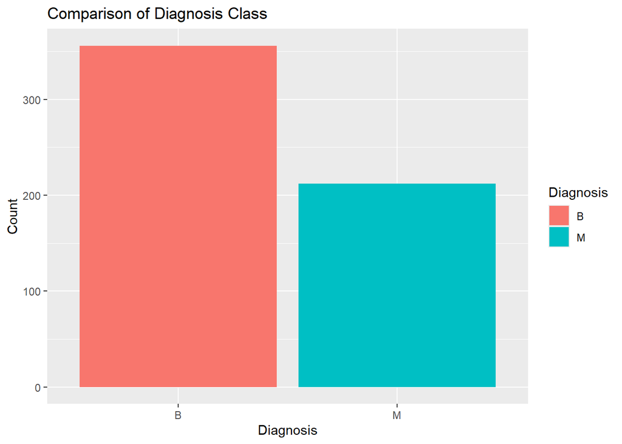

```r
diagnosis_plot <- ggplot(cancer, aes(x=diagnosis, fill=diagnosis)) +
  geom_bar() +
  labs(title="Comparison of Diagnosis Class", x="Diagnosis", y="Count", fill="Diagnosis")
diagnosis_plot
```

```r
# convert response variable into binary numeric to calculate correlation with predictors
cancer_cor <- cancer %>%
  mutate(diagnosis = ifelse(diagnosis=="M",1,0))
# examine correlation between response variable and predictors
diagnosis_cor <- cor(cancer_cor)["diagnosis", ]
diagnosis_cor
```

```
              diagnosis             radius_mean            texture_mean
            1.000000000             0.730060409             0.417610112
         perimeter_mean               area_mean         smoothness_mean
            0.742716605             0.708659334             0.357584887
       compactness_mean          concavity_mean     concave.points_mean
            0.595978844             0.695972573             0.776396257
          symmetry_mean  fractal_dimension_mean               radius_se
            0.329753554            -0.013609644             0.567337589
             texture_se            perimeter_se                 area_se
           -0.007788668             0.556230066             0.547994823
          smoothness_se          compactness_se            concavity_se
           -0.066984236             0.291921244             0.252675902
      concave.points_se             symmetry_se    fractal_dimension_se
            0.406972235            -0.005506013             0.077503649
           radius_worst           texture_worst         perimeter_worst
            0.776306336             0.458414893             0.782794681
             area_worst        smoothness_worst       compactness_worst
            0.733496292             0.420442920             0.590426637
        concavity_worst    concave.points_worst          symmetry_worst
            0.659172930             0.793743025             0.416447603
fractal_dimension_worst
            0.323182507
```

```r
# using 0.6 as a cutoff, identify variables that appear to be moderately to strongly correlated with diagnosis
high_corr <- names(diagnosis_cor[abs(diagnosis_cor)>0.6])
high_corr
```

```
 [1] "diagnosis"            "radius_mean"          "perimeter_mean"
 [4] "area_mean"            "concavity_mean"       "concave.points_mean"
 [7] "radius_worst"         "perimeter_worst"      "area_worst"
[10] "concavity_worst"      "concave.points_worst"
```

*Based on the values of their correlation coefficients, none of the standard error variables appeared to be strongly correlated with diagnosis, so they are not likely to be strong indicators of the response. Similarly, none of the variables for texture, smoothness, compactness, symmetry, or fractal dimension appear to be strongly correlated with response, so they may not be useful predictors of the response either. This leaves us with the mean and maximum values of the radius, perimeter, area, concavity, and concave points as variables we will expect to potentially be the most important predictors our models will use to make predictions for the diagnosis.*

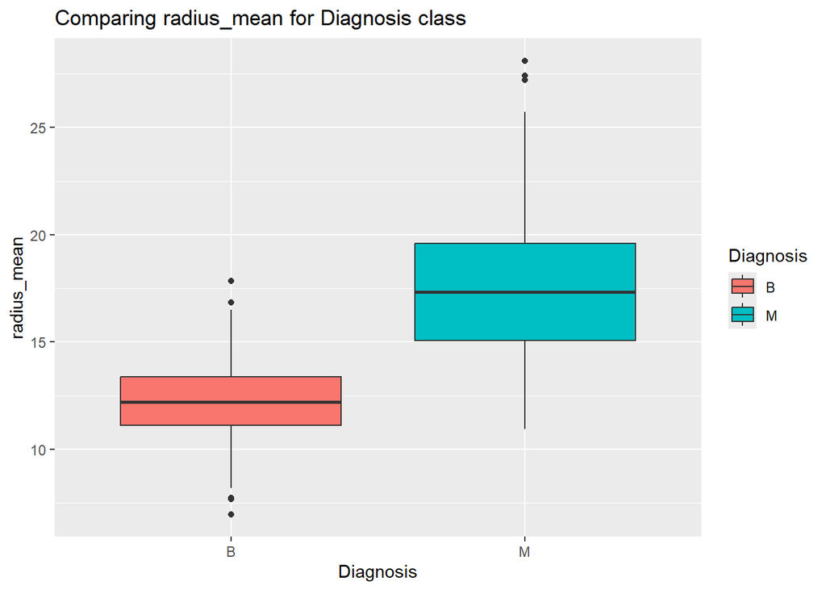

```r
# create boxplot to examine radius_mean for each class of Diagnosis
ggplot(cancer, aes(x=diagnosis, y=radius_mean, fill=diagnosis)) +
  geom_boxplot() +
  labs(title="Comparing radius_mean for Diagnosis class", x="Diagnosis",fill="Diagnosis")
```

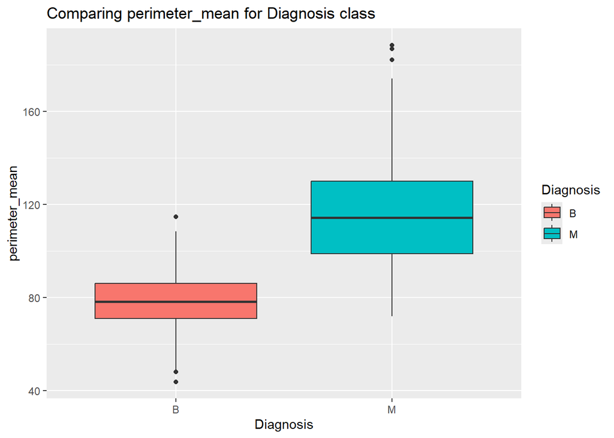

```r
# create boxplot to examine perimeter_mean for each class of Diagnosis
ggplot(cancer, aes(x=diagnosis, y=perimeter_mean, fill=diagnosis)) +
  geom_boxplot() +
  labs(title="Comparing perimeter_mean for Diagnosis class", x="Diagnosis",fill="Diagnosis")
```

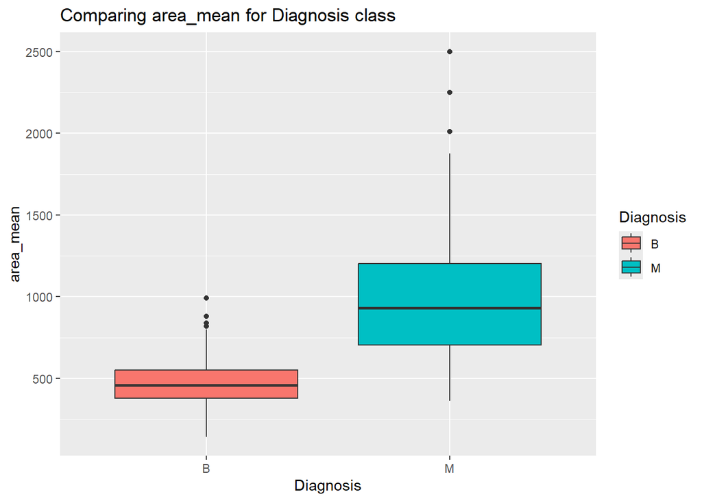

```r
# create boxplot to examine area_mean for each class of Diagnosis
ggplot(cancer, aes(x=diagnosis, y=area_mean, fill=diagnosis)) +
  geom_boxplot() +
  labs(title="Comparing area_mean for Diagnosis class", x="Diagnosis",fill="Diagnosis")
```

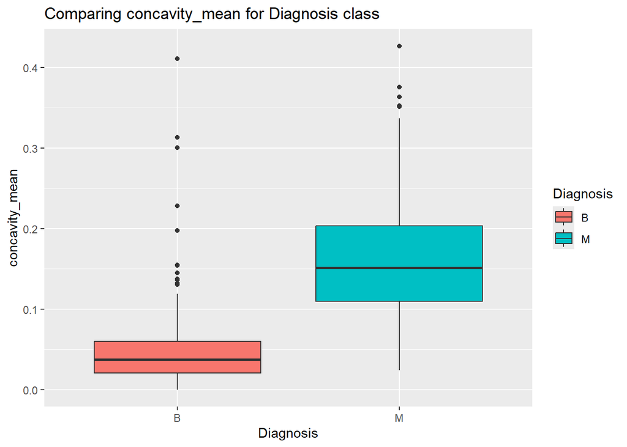

```r
# create boxplot to examine concavity_mean for each class of Diagnosis
ggplot(cancer, aes(x=diagnosis, y=concavity_mean, fill=diagnosis)) +
  geom_boxplot() +
  labs(title="Comparing concavity_mean for Diagnosis class", x="Diagnosis",fill="Diagnosis")
```

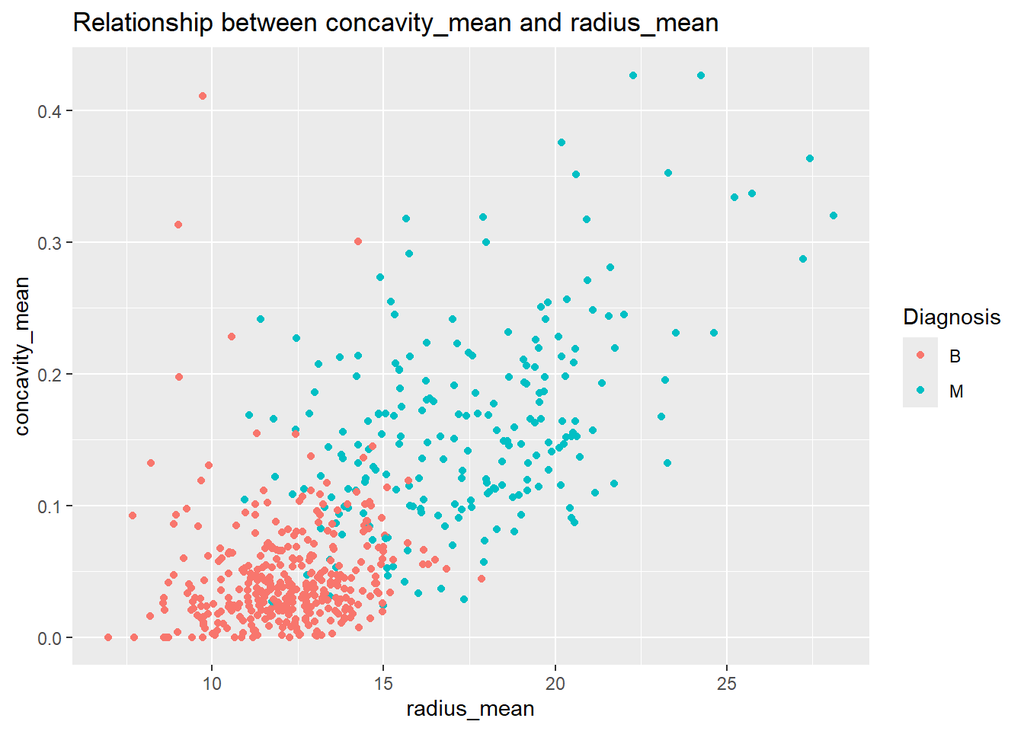

```r
# create boxplot to examine concavity_mean vs radius mean
ggplot(cancer, aes(x=radius_mean, y=concavity_mean, color=diagnosis)) +
  geom_point() +
  labs(title="Relationship between concavity_mean and radius_mean",color="Diagnosis")
```

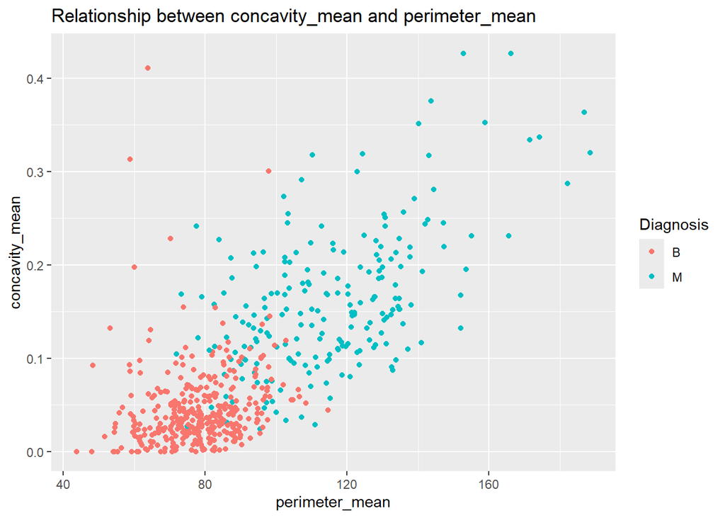

```r
# create boxplot to examine concavity_mean vs perimeter_mean
ggplot(cancer, aes(x=perimeter_mean, y=concavity_mean, color=diagnosis)) +
  geom_point() +
  labs(title="Relationship between concavity_mean and perimeter_mean",color="Diagnosis")
```

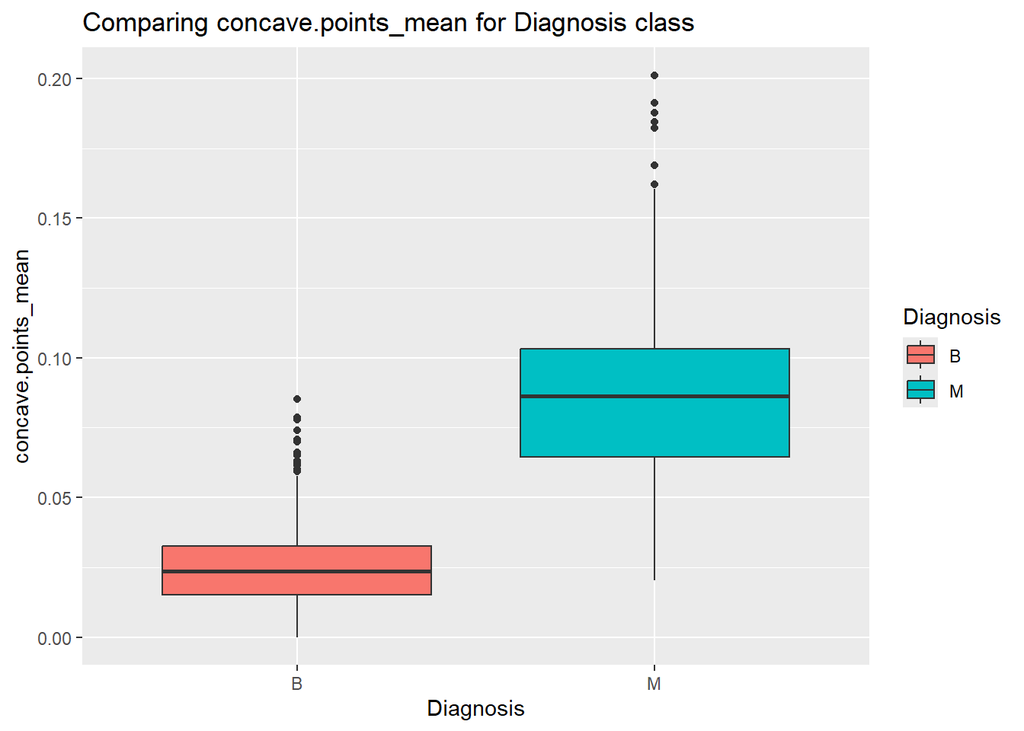

```r
# create boxplot to examine concave.points_mean for each class of Diagnosis
ggplot(cancer, aes(x=diagnosis, y=concave.points_mean, fill=diagnosis)) +
  geom_boxplot() +
  labs(title="Comparing concave.points_mean for Diagnosis class", x="Diagnosis",fill="Diagnosis")
```

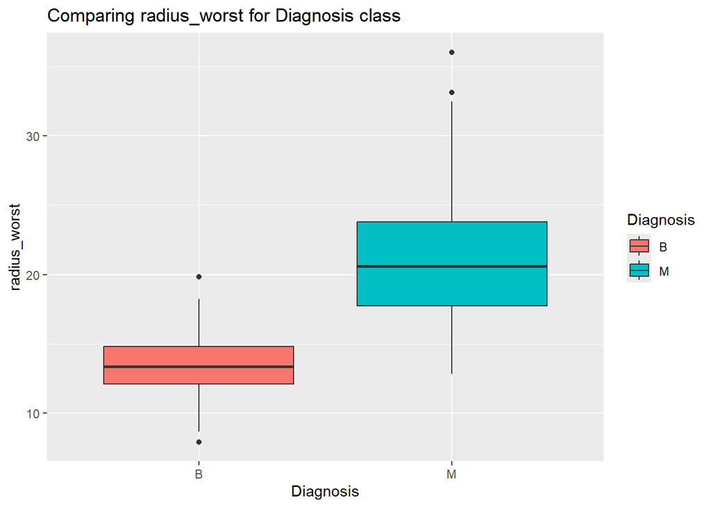

```r
# create boxplot to examine radius_worst for each class of Diagnosis
ggplot(cancer, aes(x=diagnosis, y=radius_worst, fill=diagnosis)) +
  geom_boxplot() +
  labs(title="Comparing radius_worst for Diagnosis class", x="Diagnosis",fill="Diagnosis")
```

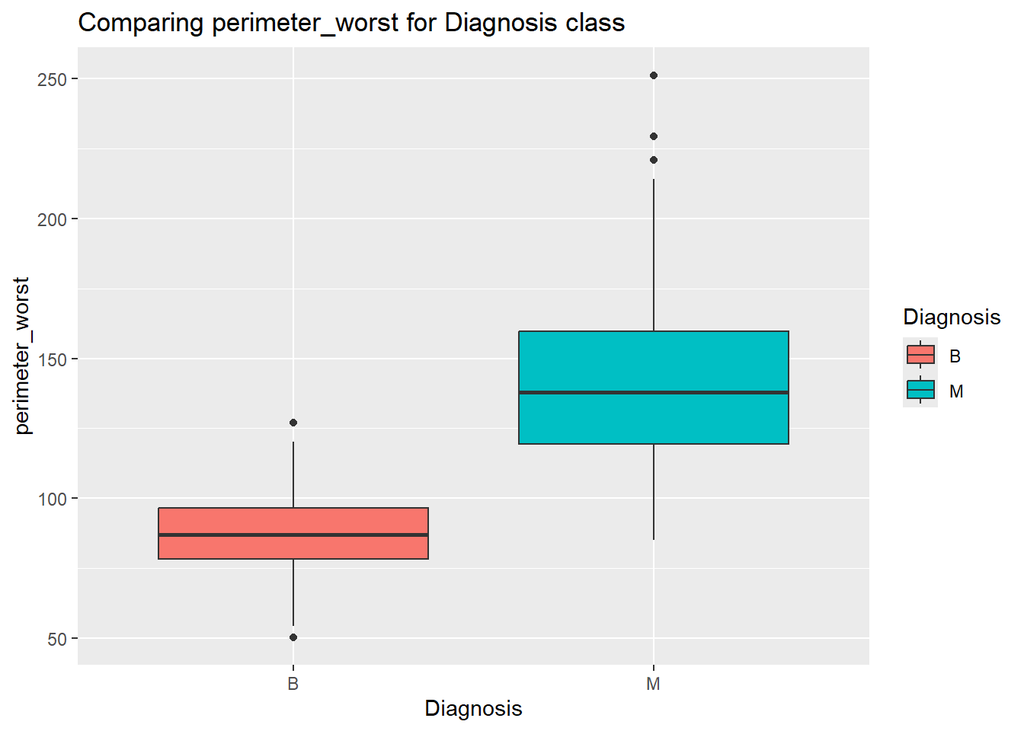

```r
# create boxplot to examine perimeter_worst for each class of Diagnosis
ggplot(cancer, aes(x=diagnosis, y=perimeter_worst, fill=diagnosis)) +
  geom_boxplot() +
  labs(title="Comparing perimeter_worst for Diagnosis class", x="Diagnosis",fill="Diagnosis")
```

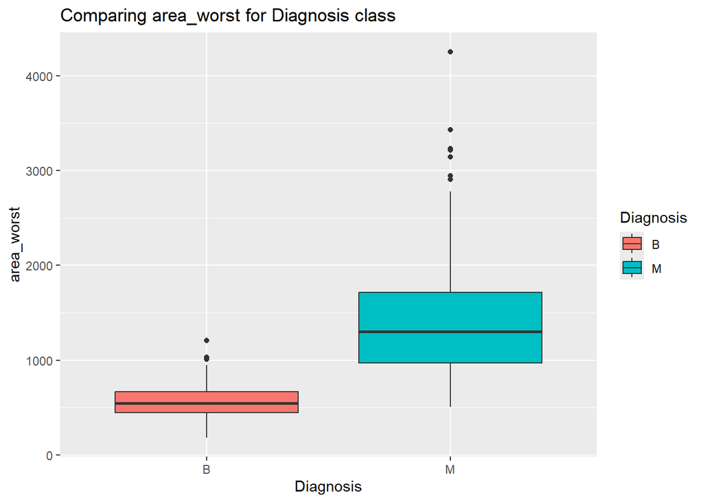

```r
# create boxplot to examine area_worst for each class of Diagnosis
ggplot(cancer, aes(x=diagnosis, y=area_worst, fill=diagnosis)) +
  geom_boxplot() +
  labs(title="Comparing area_worst for Diagnosis class", x="Diagnosis",fill="Diagnosis")
```

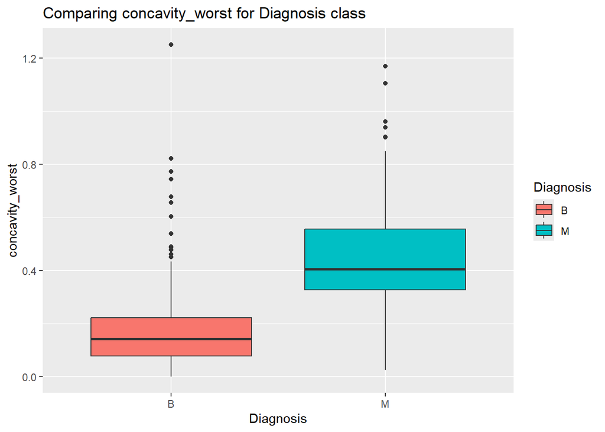

```r
# create boxplot to examine concavity_worst for each class of Diagnosis
ggplot(cancer, aes(x=diagnosis, y=concavity_worst, fill=diagnosis)) +
  geom_boxplot() +
  labs(title="Comparing concavity_worst for Diagnosis class", x="Diagnosis",fill="Diagnosis")
```

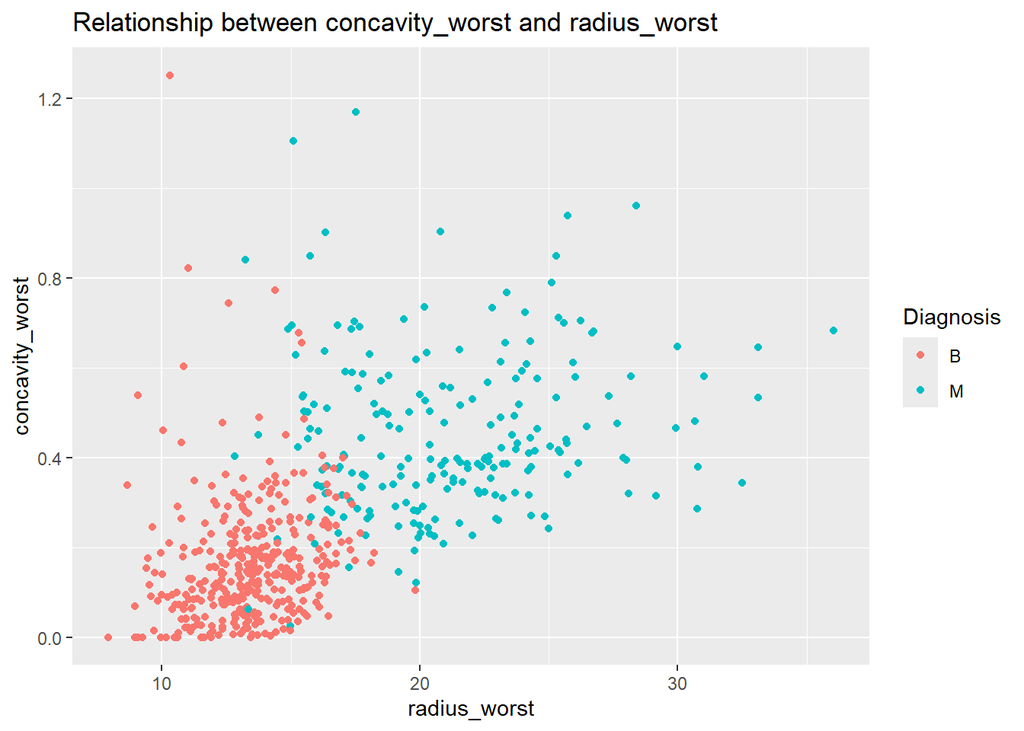

```r
# create boxplot to examine concavity_worst vs radius_worst
ggplot(cancer, aes(x=radius_worst, y=concavity_worst, color=diagnosis)) +
  geom_point() +
  labs(title="Relationship between concavity_worst and radius_worst",color="Diagnosis")
```

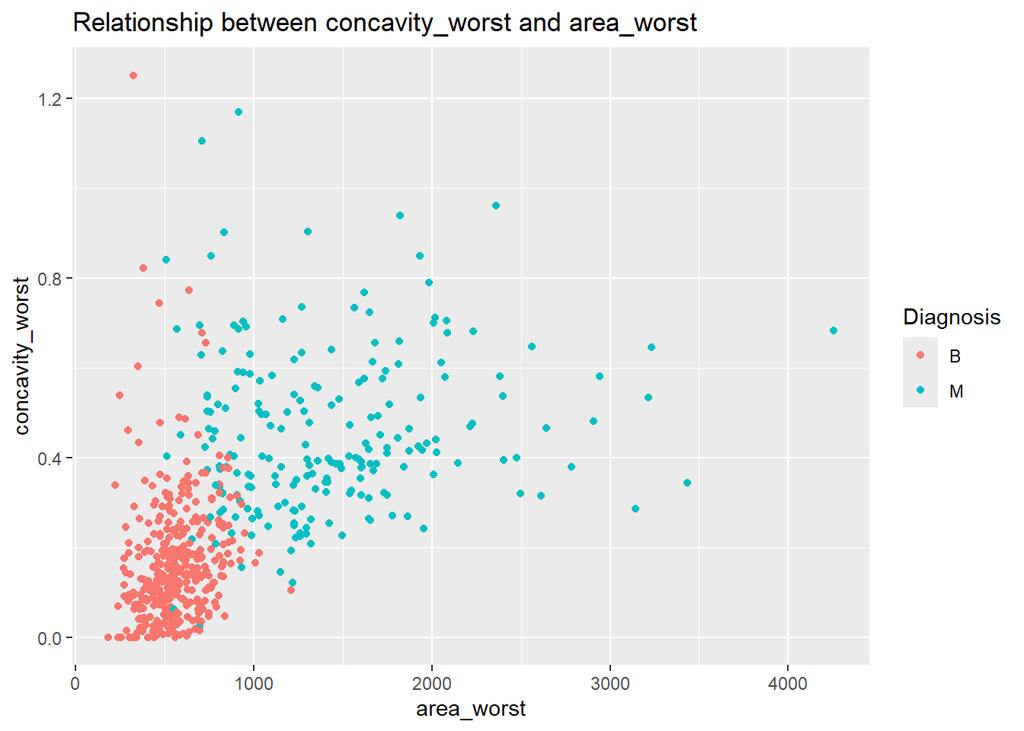

```r
# create boxplot to examine concavity_worst vs area_worst
ggplot(cancer, aes(x=area_worst, y=concavity_worst, color=diagnosis)) +
  geom_point() +
  labs(title="Relationship between concavity_worst and area_worst",color="Diagnosis")
```

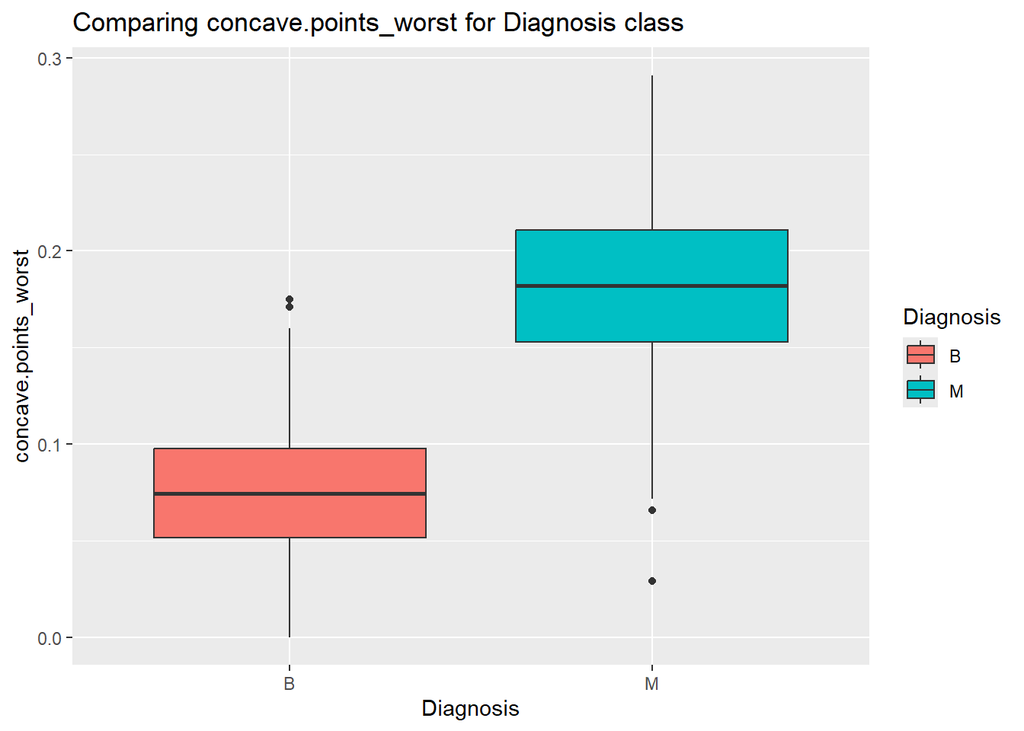

```r
# create boxplot to examine concave.points_worst for each class of Diagnosis
ggplot(cancer, aes(x=diagnosis, y=concave.points_worst, fill=diagnosis)) +
  geom_boxplot() +
  labs(title="Comparing concave.points_worst for Diagnosis class", x="Diagnosis",fill="Diagnosis")
```

*As we can see in the plots above, malignant tissue masses appear to generally have higher values for the mean and maximum measurements of radius, perimeter, area, concavity, and concave points. Both measurements of concavity appear to have upper outliers for benign tumors that on their own may lead someone to believe that the tissue mass is malignant, but as we see in the scatter plots above, whether or not these points also have large values for the other characteristics such as radius or perimeter appears to play a significant role in the classification of these points, indicating that the combination of these predictors is a good one as they both provide relevant information in determining the classification of the response variable, diagnosis.*

## Part 3: Split the data into test and training sets

```r
#Setting seed for reproducibility
set.seed(1842)
#Getting the number of rows of the data
n <- nrow(cancer)
#Randomly selecting test indices which is 20% of the data
test_index <- sample.int(n, size = round(0.2 * n))
#Dividing data into a training and a test set, dividing the data randomly with 80% of the data in the training set and 20% in the test set
test_cancer <- cancer[test_index, ]
train_cancer <- cancer[-test_index, ]
#Providing a glimpse of the test dataset
glimpse(test_cancer)
```

```
Rows: 114
Columns: 31
$ diagnosis               <fct> M, B, B, M, B, M, M, M, B, B, B, B, B, B, B, B…
$ radius_mean             <dbl> 20.290, 13.560, 8.888, 25.730, 14.220, 20.340,…
$ texture_mean            <dbl> 14.34, 13.90, 14.64, 17.46, 27.85, 21.51, 20.8…
$ perimeter_mean          <dbl> 135.10, 88.59, 58.79, 174.20, 92.55, 135.90, 9…
$ area_mean               <dbl> 1297.0, 561.3, 244.0, 2010.0, 623.9, 1264.0, 5…
$ smoothness_mean         <dbl> 0.10030, 0.10510, 0.09783, 0.11490, 0.08223, 0…
$ compactness_mean        <dbl> 0.13280, 0.11920, 0.15310, 0.23630, 0.10390, 0…
$ concavity_mean          <dbl> 0.198000, 0.078600, 0.086060, 0.336800, 0.1103…
$ concave.points_mean     <dbl> 0.104300, 0.044510, 0.028720, 0.191300, 0.0440…
$ symmetry_mean           <dbl> 0.1809, 0.1962, 0.1902, 0.1956, 0.1342, 0.2569…
$ fractal_dimension_mean  <dbl> 0.05883, 0.06303, 0.08980, 0.06121, 0.06129, 0…
$ radius_se               <dbl> 0.7572, 0.2569, 0.5262, 0.9948, 0.3354, 0.5702…
$ texture_se              <dbl> 0.7813, 0.4981, 0.8522, 0.8509, 2.3240, 1.0230…
```

[output cut: 18 more lines]

```r
#Providing a glimpse of the training dataset
glimpse(train_cancer)
```

```
Rows: 454
Columns: 31
$ diagnosis               <fct> M, M, M, M, M, M, M, M, M, M, M, M, M, M, M, M…
$ radius_mean             <dbl> 17.990, 20.570, 19.690, 11.420, 12.450, 18.250…
$ texture_mean            <dbl> 10.38, 17.77, 21.25, 20.38, 15.70, 19.98, 21.8…
$ perimeter_mean          <dbl> 122.80, 132.90, 130.00, 77.58, 82.57, 119.60, …
$ area_mean               <dbl> 1001.0, 1326.0, 1203.0, 386.1, 477.1, 1040.0, …
$ smoothness_mean         <dbl> 0.11840, 0.08474, 0.10960, 0.14250, 0.12780, 0…
$ compactness_mean        <dbl> 0.27760, 0.07864, 0.15990, 0.28390, 0.17000, 0…
$ concavity_mean          <dbl> 0.30010, 0.08690, 0.19740, 0.24140, 0.15780, 0…
$ concave.points_mean     <dbl> 0.14710, 0.07017, 0.12790, 0.10520, 0.08089, 0…
$ symmetry_mean           <dbl> 0.2419, 0.1812, 0.2069, 0.2597, 0.2087, 0.1794…
$ fractal_dimension_mean  <dbl> 0.07871, 0.05667, 0.05999, 0.09744, 0.07613, 0…
$ radius_se               <dbl> 1.0950, 0.5435, 0.7456, 0.4956, 0.3345, 0.4467…
$ texture_se              <dbl> 0.9053, 0.7339, 0.7869, 1.1560, 0.8902, 0.7732…
```

[output cut: 18 more lines]

## Part 4: Build a classification algorithm using decision trees

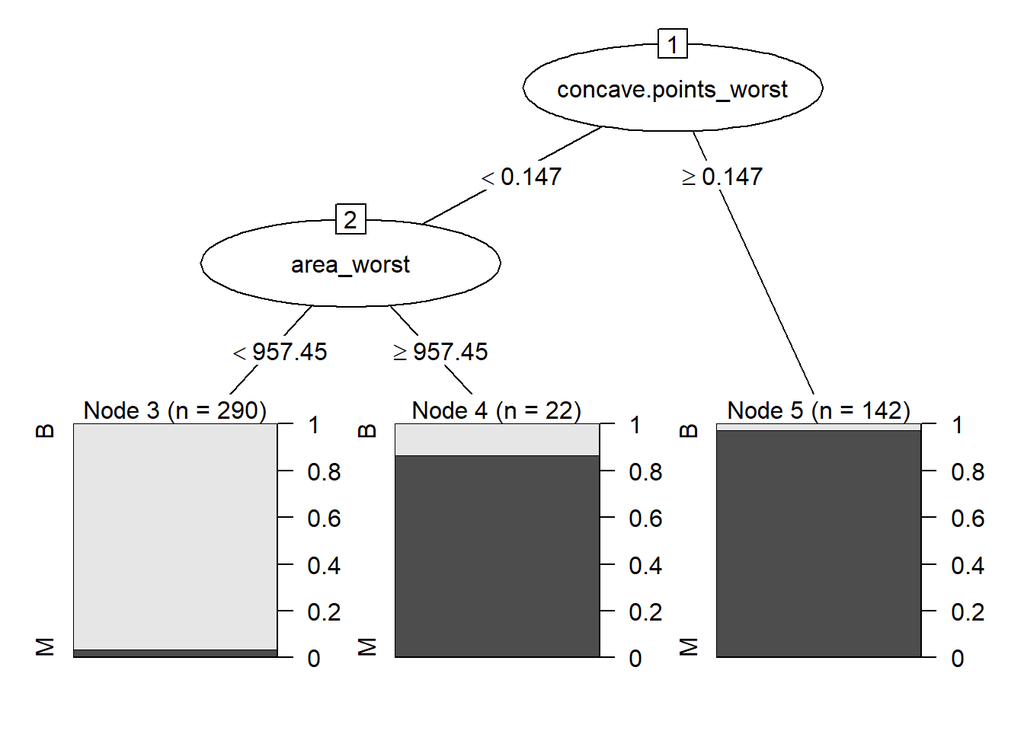

```r
#Predicting the diagnosis variable from the rest of the variables in the data
form_cancer <- as.formula(diagnosis ~ .)
#create the decision tree predicting diagnosis from predictors in training data
cancer_tree <- rpart(form_cancer, data=train_cancer)
plot(as.party(cancer_tree))
```

```r
printcp(cancer_tree)
```

```
Classification tree:
rpart(formula = form_cancer, data = train_cancer)

Variables actually used in tree construction:
[1] area_worst           concave.points_worst

Root node error: 167/454 = 0.36784

n= 454

        CP nsplit rel error  xerror     xstd
1 0.802395      0    1.0000 1.00000 0.061525
2 0.095808      1    0.1976 0.22754 0.035334
3 0.010000      2    0.1018 0.13772 0.027981
```

```r
# use the decision tree to predict diagnosis for the test data
test_cancer$preds_tree <- predict(cancer_tree, newdata = test_cancer, "class")
# create a confusion matrix to show predicted vs actual results
conf_tree <- table(test_cancer$diagnosis, test_cancer$preds_tree,
                   dnn=c("actual", "predicted"))
conf_tree
```

```
      predicted
actual  B  M
     B 65  4
     M  6 39
```

```r
# calculate the accuracy of decision tree predictions
acc_tree <- sum(diag(conf_tree))/sum(conf_tree)
acc_tree
```

```
[1] 0.9122807
```

As we can see in the output above, the decision tree only has two potential splits. It first looks at the concave.points_worst value, and if that number is greater than or equal to 0.147, that tissue mass is predicted to be malignant. If that value is less than 0.147, the tree then looks at the area_worst variable, with any tissue mass with a value greater than or equal to 957.45 predicted to be malignant and any with a value less than 957.45 predicted to be benign. When this decision tree is applied to our test data, 65 observations are correctly predicted as benign and 39 are correctly predicted as malignant, while 6 are incorrectly predicted as benign and 4 are incorrectly predicted as malignant. This gives us an overall accuracy of about 91.23%, which does make it seem to be effective. However, a potential concern is that this tree could be sensitive to small change in data. For example, we saw in the boxplot above that concave.points_worst has the potential for lower outliers. which could make one of these observations more susceptible to a false negative prediction if area_worst also misses the threshold. We also saw in the boxplot that this variable has the potential for upper outliers in benign tissues, potentially causing these observations to be immediately classified as malignant after looking at only one measurement.  
The rpart function should automatically pre-prune the decision tree based on CP. We have established a larger decision tree below and pruned it appropriately to demonstrate this.

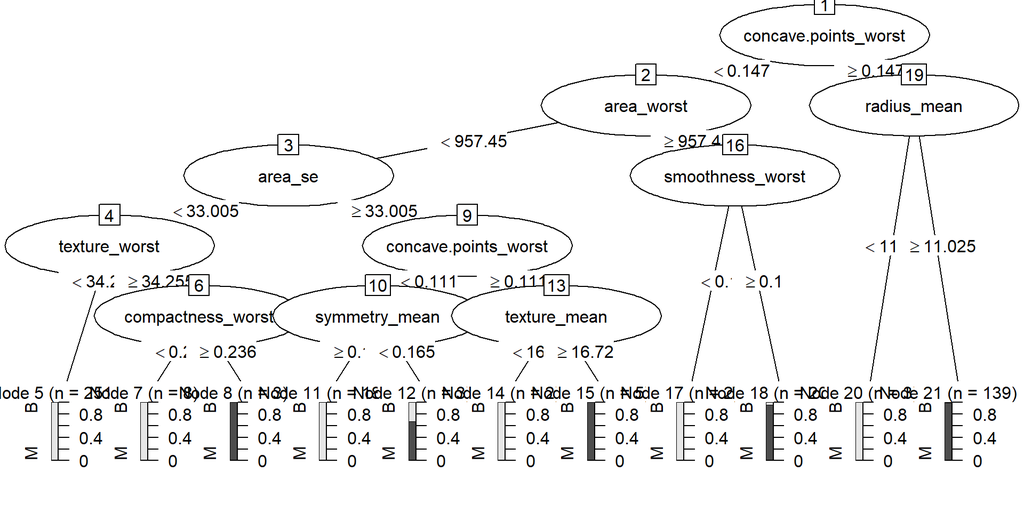

```r
# create a "bigger" tree to show rpart has already pre-pruned our tree
cancer_tree2 <- rpart(form_cancer, data=train_cancer, minsplit=7, cp=0)
plot(as.party(cancer_tree2))
```

```r
printcp(cancer_tree2)
```

```
Classification tree:
rpart(formula = form_cancer, data = train_cancer, minsplit = 7,
    cp = 0)

Variables actually used in tree construction:
[1] area_se              area_worst           compactness_worst
[4] concave.points_worst radius_mean          smoothness_worst
[7] symmetry_mean        texture_mean         texture_worst

Root node error: 167/454 = 0.36784

n= 454

        CP nsplit rel error  xerror     xstd
1 0.802395      0  1.000000 1.00000 0.061525
2 0.095808      1  0.197605 0.22156 0.034908
3 0.017964      2  0.101796 0.13174 0.027397
4 0.011976      3  0.083832 0.13772 0.027981
5 0.008982      4  0.071856 0.16766 0.030693
6 0.005988      9  0.023952 0.19162 0.032658
7 0.000000     10  0.017964 0.19760 0.033125
```

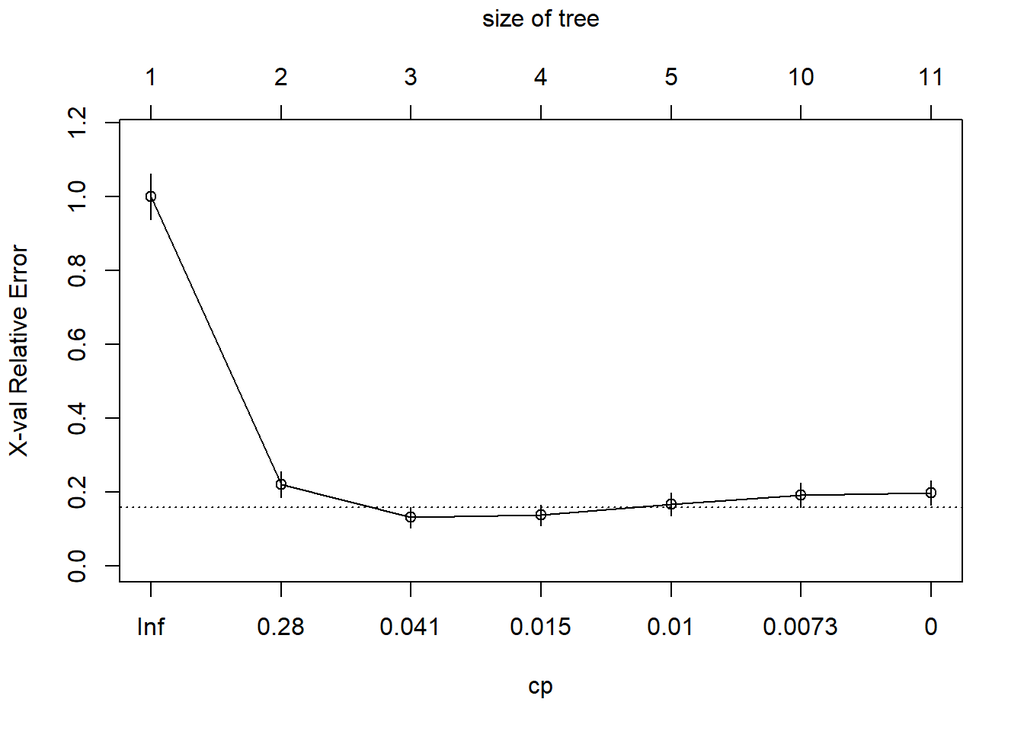

```r
# use plotcp to identify the ideal cp value
plotcp(cancer_tree2)
```

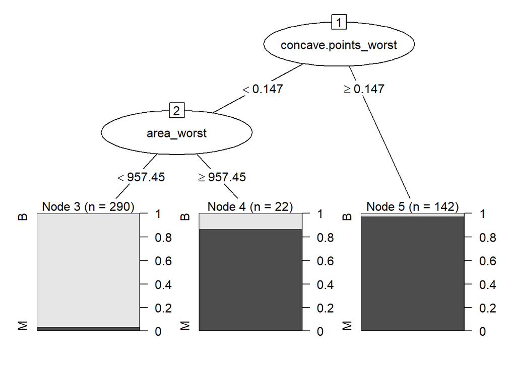

```r
# plot the bigger tree, pruned down with cp=0.041
plot(as.party(prune(cancer_tree2,cp=0.041)))
```

```r
# make predictions using the bigger tree pruned with identified cp value
test_cancer$preds_tree2 <- predict(prune(cancer_tree2,0.041), newdata = test_cancer, "class")
# create confusion matrix of actual vs predicted values
conf_tree2 <- table(test_cancer$diagnosis, test_cancer$preds_tree2,
                   dnn=c("actual", "predicted"))
conf_tree2
```

```
      predicted
actual  B  M
     B 65  4
     M  6 39
```

```r
# calculate the accuracy of this decision tree
acc_tree2 <- sum(diag(conf_tree2))/sum(conf_tree2)
acc_tree2
```

```
[1] 0.9122807
```

*After pruning the tree to the appropriate CP value determined from the plot, we see we end up with the same decision tree and prediction results that we did with our initial tree.*

## Part 5: Build a classification algorithm using random forests

```r
#Setting seed for reproducibility
set.seed(1842)
#Training the random forest model with 200 trees, randomly selecting 5 variables at each split in the tree
forest_cancer <- randomForest(formula = form_cancer, data = train_cancer, mtry = 5, ntree = 200)
#Printing the output for the model
forest_cancer
```

```
Call:
 randomForest(formula = form_cancer, data = train_cancer, mtry = 5,      ntree = 200)
               Type of random forest: classification
                     Number of trees: 200
No. of variables tried at each split: 5

        OOB estimate of  error rate: 3.08%
Confusion matrix:
    B   M class.error
B 281   6  0.02090592
M   8 159  0.04790419
```

*The Random Forest model performed well with an OOB (Out-of-Bag) error rate of 3.08%, meaning it made very few mistakes when tested on unseen data. Looking at the confusion matrix, the model correctly identified 281 benign cases (non-cancerous) and 159 malignant cases (cancerous). However, it made a few errors: it incorrectly labeled 6 benign cases as malignant and 8 malignant cases as benign. In terms of accuracy, the model made only 2.1% errors in identifying benign cases and 4.8% errors in identifying malignant cases. Overall, this shows that the model is performing well, with slightly more difficulty in correctly classifying malignant cases compared to benign ones.*

```r
#Predicting the test data
forest_pred <- predict(forest_cancer, newdata = test_cancer)
#Creating a confusion matrix comparing actual vs predicted values
conf_forest <- table(Predicted = forest_pred, Actual = test_cancer$diagnosis)
#Printing the confusion matrix
conf_forest
```

```
         Actual
Predicted  B  M
        B 66  4
        M  3 41
```

```r
#Calculate accuracy of the random forest
acc_forest <- sum(diag(conf_forest))/sum(conf_forest)
acc_forest
```

```
[1] 0.9385965
```

```r
 #Producing a table giving the importance of each variable in the model using mtry = 5, ntree = 200
importance(forest_cancer)
```

```
                        MeanDecreaseGini
radius_mean                   14.2013290
texture_mean                   2.6726284
perimeter_mean                12.7053525
area_mean                      9.7273022
smoothness_mean                1.1751847
compactness_mean               2.8837770
concavity_mean                 7.7506089
concave.points_mean           27.2565922
symmetry_mean                  0.7318153
fractal_dimension_mean         0.8550433
radius_se                      1.4837741
texture_se                     0.7506354
perimeter_se                   2.7541303
area_se                        8.4479813
smoothness_se                  0.8988292
compactness_se                 0.8517936
concavity_se                   1.4120803
concave.points_se              1.1087627
symmetry_se                    1.3579692
fractal_dimension_se           0.8721055
radius_worst                  21.3558229
texture_worst                  2.8536436
perimeter_worst               23.2800091
area_worst                    18.2904611
smoothness_worst               2.3597636
compactness_worst              4.6979158
concavity_worst                6.8507996
concave.points_worst          27.5255155
symmetry_worst                 2.3154956
fractal_dimension_worst        1.4448606
```

## Part 6: Build a classification algorithm using K-Nearest Neighbors

```r
# reset the test dataset to use in the knn function
test_cancer <- cancer[test_index,]
# build the knn model with k = 1
knn_cancer <- knn(train_cancer[-1],test=test_cancer[-1],cl=train_cancer$diagnosis,k=1)
# create confusion matrix comparing actual vs predicted values
conf_knn <- table(knn_cancer,test_cancer$diagnosis)
conf_knn
```

```
knn_cancer  B  M
         B 63  5
         M  6 40
```

```r
# calculate accuracy of the knn model
acc_knn <- sum(diag(conf_knn))/sum(conf_knn)
acc_knn
```

```
[1] 0.9035088
```

*The KNN was able to hold a 90.35% accuracy rating for detecting a positive diagnosis. The way KNN works is similar to a pond full of Lilly pads with a frog hopping from pad to pad. The frog wont jump 20 feet away, but might jump to the next pad 2 feet away. Similarly, KNN gives an input to each data point and gives a prediction based on them. In this case, the predictions were 90.35%.*

## Part 7: Build a classification algorithm using logistic regression

```r
library(MASS)
library(caret)
```

*Below are the variables the company would like to test as predictors to a diagnosis. They are put into the logistic regression function to find the results.*

```r
# fit the glm model with the selected predictors
cancer_glm <- glm(diagnosis ~ radius_mean + texture_se + perimeter_se + area_se + smoothness_mean + compactness_mean + concavity_mean + concave.points_mean + symmetry_se + fractal_dimension_mean, data = cancer, family = binomial)
# display the summary of the model
summary(cancer_glm)
```

```
Call:
glm(formula = diagnosis ~ radius_mean + texture_se + perimeter_se +
    area_se + smoothness_mean + compactness_mean + concavity_mean +
    concave.points_mean + symmetry_se + fractal_dimension_mean,
    family = binomial, data = cancer)

Coefficients:
                        Estimate Std. Error z value Pr(>|z|)
(Intercept)             -5.71366    5.77779  -0.989  0.32271
radius_mean              0.26789    0.21159   1.266  0.20549
texture_se              -0.09240    0.47235  -0.196  0.84490
perimeter_se            -1.13538    0.55272  -2.054  0.03996 *
area_se                  0.12409    0.04207   2.950  0.00318 **
smoothness_mean         24.43619   27.92492   0.875  0.38154
compactness_mean        10.34110   12.34469   0.838  0.40220
concavity_mean          14.10190    7.78428   1.812  0.07005 .
concave.points_mean     51.36061   25.02747   2.052  0.04015 *
symmetry_se            -45.06747   27.06472  -1.665  0.09588 .
fractal_dimension_mean -93.90444   71.61719  -1.311  0.18979
---
Signif. codes:  0 '***' 0.001 '**' 0.01 '*' 0.05 '.' 0.1 ' ' 1

(Dispersion parameter for binomial family taken to be 1)

    Null deviance: 750.51  on 567  degrees of freedom
Residual deviance: 188.61  on 557  degrees of freedom
AIC: 210.61

Number of Fisher Scoring iterations: 8
```

*There are ways to weed out models with too many un-needed variables. The AIC functions from the MASS package can help us with this.*

```r
AIC(cancer_glm)
```

```
[1] 210.6056
```

```r
stepAIC(cancer_glm)
```

```
Start:  AIC=210.61
diagnosis ~ radius_mean + texture_se + perimeter_se + area_se +
    smoothness_mean + compactness_mean + concavity_mean + concave.points_mean +
    symmetry_se + fractal_dimension_mean

                         Df Deviance    AIC
- texture_se              1   188.64 208.64
- compactness_mean        1   189.30 209.30
- smoothness_mean         1   189.38 209.38
- radius_mean             1   190.27 210.27
- fractal_dimension_mean  1   190.37 210.37
<none>                        188.61 210.61
- symmetry_se             1   191.36 211.36
- concavity_mean          1   192.03 212.03
- concave.points_mean     1   193.01 213.01
- perimeter_se            1   193.14 213.14
- area_se                 1   199.11 219.11

Step:  AIC=208.64
diagnosis ~ radius_mean + perimeter_se + area_se + smoothness_mean +
    compactness_mean + concavity_mean + concave.points_mean +
    symmetry_se + fractal_dimension_mean

                         Df Deviance    AIC
- compactness_mean        1   189.36 207.36
- smoothness_mean         1   189.42 207.42
- fractal_dimension_mean  1   190.39 208.39
- radius_mean             1   190.51 208.51
<none>                        188.64 208.64
- symmetry_se             1   191.51 209.51
- concavity_mean          1   192.05 210.05
- concave.points_mean     1   193.07 211.07
- perimeter_se            1   193.42 211.42
- area_se                 1   199.12 217.12

Step:  AIC=207.36
diagnosis ~ radius_mean + perimeter_se + area_se + smoothness_mean +
    concavity_mean + concave.points_mean + symmetry_se + fractal_dimension_mean

                         Df Deviance    AIC
```

[output cut: 21 more lines]

```
- area_se                 1   200.68 214.68
- concave.points_mean     1   208.34 222.34

Step:  AIC=204.64
diagnosis ~ radius_mean + perimeter_se + area_se + concavity_mean +
    concave.points_mean + symmetry_se

                      Df Deviance    AIC
<none>                     190.65 204.65
- concavity_mean       1   193.52 205.52
- symmetry_se          1   193.89 205.89
- perimeter_se         1   195.61 207.61
- radius_mean          1   196.58 208.58
- area_se              1   201.71 213.71
- concave.points_mean  1   209.15 221.15
```

```
Call:  glm(formula = diagnosis ~ radius_mean + perimeter_se + area_se +
    concavity_mean + concave.points_mean + symmetry_se, family = binomial,
    data = cancer)

Coefficients:
        (Intercept)          radius_mean         perimeter_se
            -9.6158               0.3439              -1.1467
            area_se       concavity_mean  concave.points_mean
             0.1236              10.2873              67.4647
        symmetry_se
           -47.4841

Degrees of Freedom: 567 Total (i.e. Null);  561 Residual
Null Deviance:      750.5
Residual Deviance: 190.6    AIC: 204.6
```

```r
# fit the model suggested by stepAIC
cancer_glm_2<- glm(formula = diagnosis ~ radius_mean + perimeter_se + area_se +
    concavity_mean + concave.points_mean + symmetry_se, family = binomial,
    data = cancer)
AIC(cancer_glm_2)
```

```
[1] 204.6446
```

*We used the AIC and stepAIC function to ensure we have the best selected model for the logistical regression. There were only 6 factors left from the origional model and achieved a lower AIC reading of 204.64 down from over 210.*

```r
# predict the response variable with the original glm model
glm_pred <- predict(cancer_glm, newdata = test_cancer, type = "response")
# create confusion matrix showing predicted vs actual results
conf_glm <- table(Predicted = round(glm_pred), Actual = test_cancer$diagnosis)
conf_glm
```

```
         Actual
Predicted  B  M
        0 66  7
        1  3 38
```

```r
# calculate accuracy of the model
acc_glm <- sum(diag(conf_glm))/sum(conf_glm)
acc_glm
```

```
[1] 0.9122807
```

```r
# predict response variable with model suggested by step AIC
glm_pred2 <- predict(cancer_glm_2, newdata = test_cancer, type = "response")
# generate confusion matrix showing predicted vs actual results
conf_glm2 <- table(Predicted = round(glm_pred2), Actual = test_cancer$diagnosis)
conf_glm2
```

```
         Actual
Predicted  B  M
        0 65  7
        1  4 38
```

```r
# calculate accuracy of the model
acc_glm2 <- sum(diag(conf_glm2))/sum(conf_glm2)
acc_glm2
```

```
[1] 0.9035088
```

*As we can see, even though the AIC function selected a smaller model, the original model is still better at predicting. This means we can stick with the original model. Logistic regression works by a series of binary decisions, or decisions with only 2 outcomes.*

## Part 8: Create a comparison of the different models on appropriate criteria

```r
# calculate sensitivity and specificty for the decision tree
sens_tree <- conf_tree[4] / (conf_tree[3] + conf_tree[4])
spec_tree <- conf_tree[1] / (conf_tree[1] + conf_tree[2])
# calculate sensitivity and specificity for the random forest
sens_forest <- conf_forest[4] / (conf_forest[3] + conf_forest[4])
spec_forest <- conf_forest[1] / (conf_forest[1] + conf_forest[2])
# calculate sensitivity and specificity for the knn model
sens_knn <- conf_knn[4] / (conf_knn[3] + conf_knn[4])
spec_knn <- conf_knn[1] / (conf_knn[1] + conf_knn[2])
# calculate sensitivity and specificity for the glm model
sens_glm <- conf_glm[4] / (conf_glm[3] + conf_glm[4])
spec_glm <- conf_glm[1] / (conf_glm[1] + conf_glm[2])
```

```r
# combine the values into rows to use in our comparison table
Acc <- c(acc_tree, acc_forest, acc_knn, acc_glm)
Sens <- c(sens_tree, sens_forest, sens_knn, sens_glm)
Spec <- c(spec_tree, spec_forest, spec_knn, spec_glm)
table_matrix <- rbind(Acc, Sens, Spec)
# Define column and row names
colnames(table_matrix) <- c("Decision Tree", "Random Forest", "KNN", "Logistic Regression")
rownames(table_matrix) <- c("Acc", "Sens", "Spec")
# Convert matrix to a table
model_compare <- as.table(table_matrix)
model_compare
```

```
     Decision Tree Random Forest       KNN Logistic Regression
Acc      0.9122807     0.9385965 0.9035088           0.9122807
Sens     0.9069767     0.9111111 0.8888889           0.8444444
Spec     0.9154930     0.9565217 0.9130435           0.9565217
```